# Question

Let’s consider an alternative way to multiply 98 and 35.

First, let’s break each number into its tens and ones.

$$98 ~~=~~ 90+8$$
$$35 ~~=~~ 30+5$$

Now, find all 4 indicated products. Also, find the totals.

| * | $90$ | $8$ | **total** |
| --- | --- | --- | --- |
| $30$ | ##ANSWER1## | ##ANSWER2## | ##ANSWER5## |
| $5$ | ##ANSWER3## | ##ANSWER4## | ##ANSWER6## |
| **total** | ##ANSWER7## | ##ANSWER8## | ##ANSWER9## |

## Answerlist

- 27
- 270
- 2700
- 27000
- 24
- 240
- 2400
- 24000
- 45
- 450
- 4500
- 45000
- 40
- 400
- 4000
- 40000
- 280
- 490
- 2940
- 3150
- 3430
- 280
- 490
- 2940
- 3150
- 3430
- 280
- 490
- 2940
- 3150
- 3430
- 280
- 490
- 2940
- 3150
- 3430
- 280
- 490
- 2940
- 3150
- 3430

# Solution

$$98\cdot 35 = 3430$$

| * | $90$ | $8$ | **total** |
| --- | --- | --- | --- |
| $30$ | 2700 | 240 | 2940 |
| $5$ | 450 | 40 | 490 |
| **total** | 3150 | 280 | 3430 |

At some point I learned about the [multiplication by lines](https://www.mathnstuff.com/math/spoken/here/2class/60/bylines.htm) method. You’ll notice there are 9 lines above 8 lines, both with positive slope. There are also 3 lines above 5 lines, both with negative slope. The number of intersections in the four corners are found with multiplication: $9\cdot3=27$ and $8\cdot3=24$ and $9\cdot5=45$ and $8\cdot5=40$.

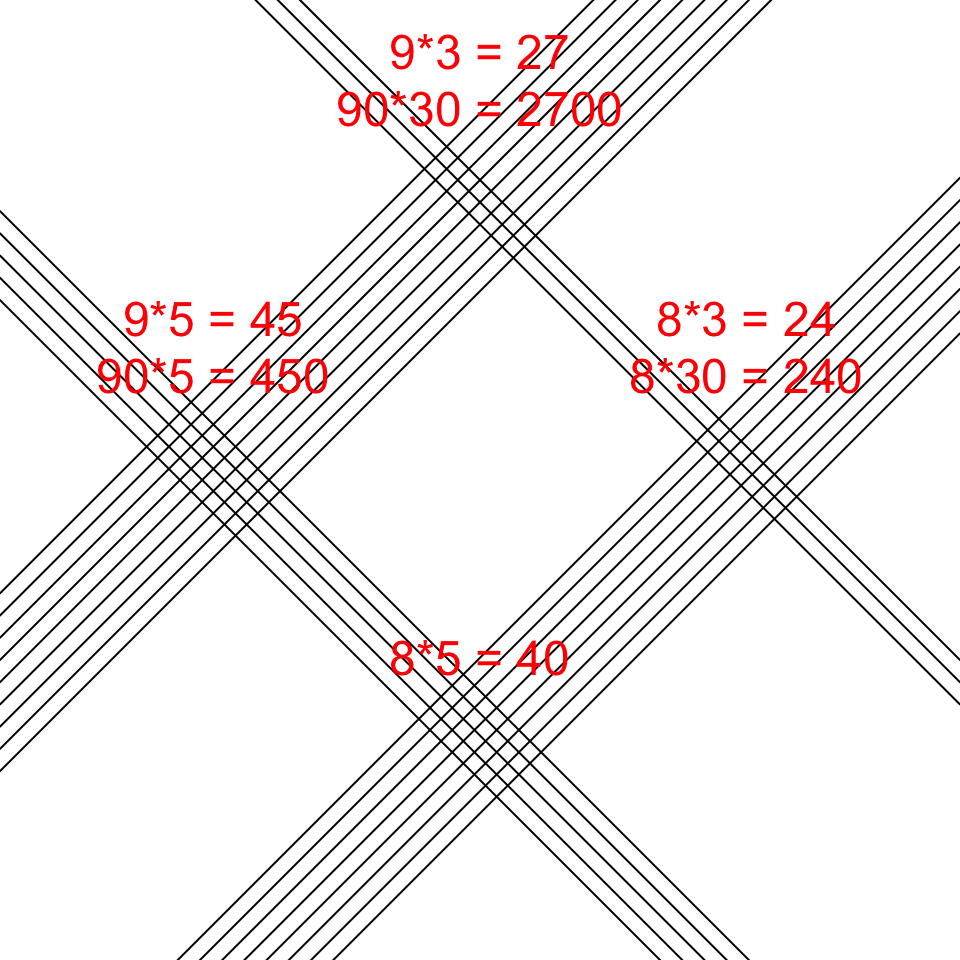

$$2700 + 240 + 450 + 40 ~~=~~
3430$$

# Meta-information

extype: cloze exclozetype: schoice|schoice|schoice|schoice|schoice|schoice|schoice|schoice|schoice exsolution: 0010|0100|0100|1000|00100|01000|00010|10000|00001 exname: multiply_2digits